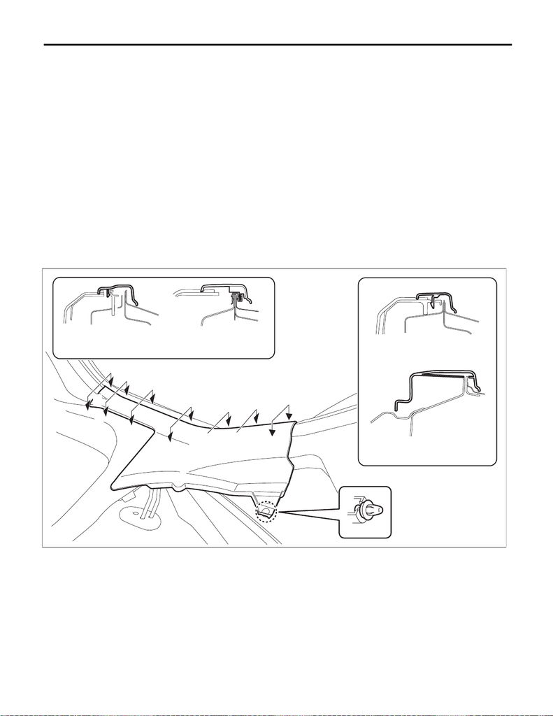

EI-92

Rear Shelf Trim

EXTERIOR/INTERIOR TRIM

26.Rear Shelf Trim

A: REMOVAL

CAUTION:

• Airbag system satellite safing sensor is located in the lower of the rear seat cushion center. Before

removing the rear seat, refer to “CAUTION” of “General Description” in “AIRBAG SYSTEM” section.

<Ref. to AB-9, CAUTION, General Description.>

• The airbag system is fitted with a backup power supply. After disconnecting the battery ground ca-

ble, the airbag may operate if you do not wait for 60 seconds before starting the service of airbag sys-

tem.

1) Disconnect the ground cable from battery and wait for at least 60 seconds before starting work. <Ref. to

NT-5, BATTERY, NOTE, Note.>

NOTE:

For models other than STI model, disconnect the ground terminal from battery sensor.

2) Remove the rear seat cushion assembly. <Ref. to SE-29, REMOVAL, Rear Seat.>

3) Release the clips and claws, and remove the side sill covers - rear INN on the left and right sides.

CAUTION:

Do not pull with excessive force. Doing so may damage the claws of the side sill cover - rear INN.

4) Remove the trim panel - rear pillar UPR and trim panel - rear pillar LWR on the RH and LH sides. <Ref.

to EI-89, REMOVAL, Rear Quarter Trim.>

EI-03497

A

A

B

B

C-C

D-D

D

D

C

C

C

C

B

B

A-A

B-B

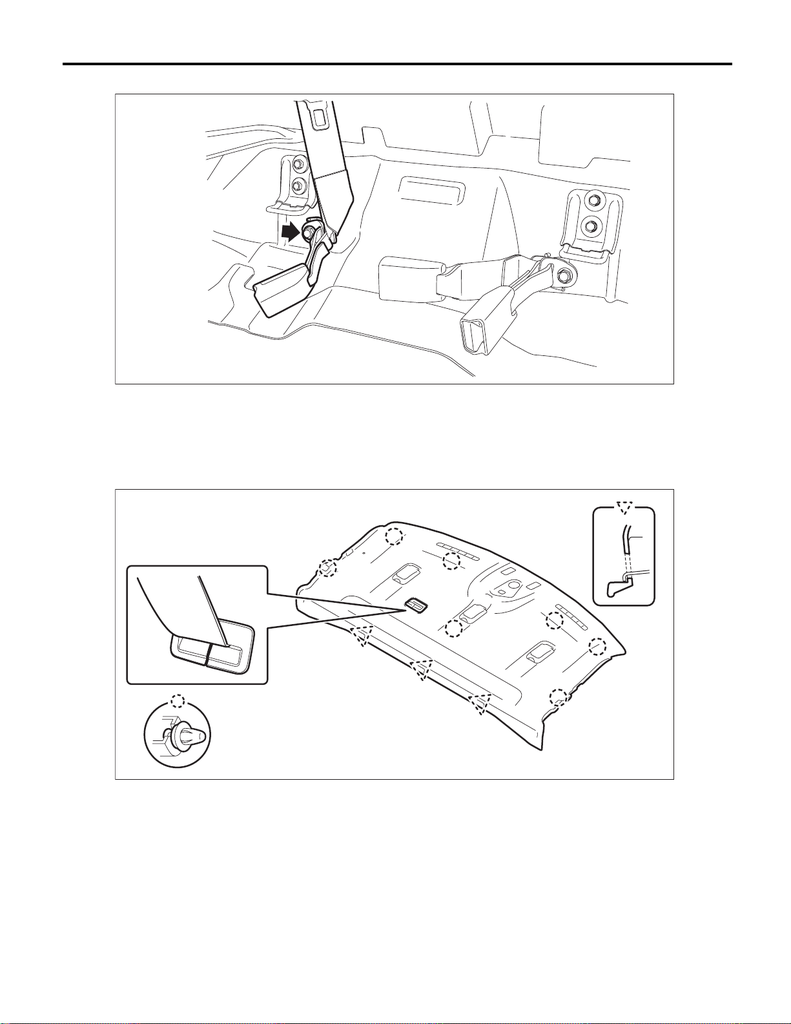

EI-93

Rear Shelf Trim

EXTERIOR/INTERIOR TRIM

5) Remove the bolts, and remove the lower anchor of the seat belt - rear shoulder CTR.

6) Remove the high-mounted stop light. <Ref. to LI-58, REMOVAL, High-mounted Stop Light.>

7) Remove the trim panel assembly - rear shelf.

(1) Release the clips to float the trim panel assembly - rear shelf.

(2) Release the belt guide, and guide the anchor of the seat belt - rear shoulder CTR to behind the trim

panel - rear shelf assembly.

(3) Remove the trim panel assembly - rear shelf.

EI-03459

EI-03515

[figure not shown]

EI-94

Rear Shelf Trim

EXTERIOR/INTERIOR TRIM

B: INSTALLATION

1) Install the trim panel assembly - rear shelf.

2) Install the high-mounted stop light.

CAUTION:

Make sure that the claw behind the light assembly - high-mounted is securely attached to the trim

panel assembly - rear shelf.

3) Install the lower anchor of seat belt - rear shoulder CTR.

Tightening torque:

30 N·m (3.1 kgf-m, 22.1 ft-lb)

4) Install the trim panel - rear pillar UPR and the trim panel - rear pillar LWR.

5) Install the side sill cover - rear INN.

6) Install the rear seat cushion assembly.

7) Connect the battery ground terminal. <Ref. to NT-5, BATTERY, NOTE, Note.>

NOTE:

For models other than STI model, connect the ground terminal to battery sensor.